# Diamond Data Analysis Project

Sashant Bhagat

2026-05-25

# Introduction

This project performs:

- Data Understanding
- Data Cleaning
- Exploratory Data Analysis (EDA)
- Statistical Analysis

using the `diamonds` dataset from the `ggplot2` package.

# Load Libraries

```r
library(tidyverse)
library(skimr)
library(janitor)

data("diamonds")
```

# Data Understanding

## Meaning of Dataset Variables

- price - Diamond price
- carat - Weight of diamond
- cut - Quality of cut
- color - Diamond color grade
- clarity - Clarity quality
- depth - Total depth percentage
- table - Width of top of diamond
- x,y,z - Dimensions

## Preview Dataset

```r
head(diamonds)
```

```
## # A tibble: 6 × 10
##   carat cut       color clarity depth table price     x     y     z
##   <dbl> <ord>     <ord> <ord>   <dbl> <dbl> <int> <dbl> <dbl> <dbl>
## 1  0.23 Ideal     E     SI2      61.5    55   326  3.95  3.98  2.43
## 2  0.21 Premium   E     SI1      59.8    61   326  3.89  3.84  2.31
## 3  0.23 Good      E     VS1      56.9    65   327  4.05  4.07  2.31
## 4  0.29 Premium   I     VS2      62.4    58   334  4.2   4.23  2.63
## 5  0.31 Good      J     SI2      63.3    58   335  4.34  4.35  2.75
## 6  0.24 Very Good J     VVS2     62.8    57   336  3.94  3.96  2.48
```

## Structure of Dataset

```r
str(diamonds)
```

```
## tibble [53,940 × 10] (S3: tbl_df/tbl/data.frame)
##  $ carat  : num [1:53940] 0.23 0.21 0.23 0.29 0.31 0.24 0.24 0.26 0.22 0.23 ...
##  $ cut    : Ord.factor w/ 5 levels "Fair"<"Good"<..: 5 4 2 4 2 3 3 3 1 3 ...
##  $ color  : Ord.factor w/ 7 levels "D"<"E"<"F"<"G"<..: 2 2 2 6 7 7 6 5 2 5 ...
##  $ clarity: Ord.factor w/ 8 levels "I1"<"SI2"<"SI1"<..: 2 3 5 4 2 6 7 3 4 5 ...
##  $ depth  : num [1:53940] 61.5 59.8 56.9 62.4 63.3 62.8 62.3 61.9 65.1 59.4 ...
##  $ table  : num [1:53940] 55 61 65 58 58 57 57 55 61 61 ...
##  $ price  : int [1:53940] 326 326 327 334 335 336 336 337 337 338 ...
##  $ x      : num [1:53940] 3.95 3.89 4.05 4.2 4.34 3.94 3.95 4.07 3.87 4 ...
##  $ y      : num [1:53940] 3.98 3.84 4.07 4.23 4.35 3.96 3.98 4.11 3.78 4.05 ...
##  $ z      : num [1:53940] 2.43 2.31 2.31 2.63 2.75 2.48 2.47 2.53 2.49 2.39 ...
```

## Summary Statistics

```r
summary(diamonds)
```

```
##      carat               cut        color        clarity          depth
##  Min.   :0.2000   Fair     : 1610   D: 6775   SI1    :13065   Min.   :43.00
##  1st Qu.:0.4000   Good     : 4906   E: 9797   VS2    :12258   1st Qu.:61.00
##  Median :0.7000   Very Good:12082   F: 9542   SI2    : 9194   Median :61.80
##  Mean   :0.7979   Premium  :13791   G:11292   VS1    : 8171   Mean   :61.75
##  3rd Qu.:1.0400   Ideal    :21551   H: 8304   VVS2   : 5066   3rd Qu.:62.50
##  Max.   :5.0100                     I: 5422   VVS1   : 3655   Max.   :79.00
##                                     J: 2808   (Other): 2531
##      table           price             x                y
##  Min.   :43.00   Min.   :  326   Min.   : 0.000   Min.   : 0.000
##  1st Qu.:56.00   1st Qu.:  950   1st Qu.: 4.710   1st Qu.: 4.720
##  Median :57.00   Median : 2401   Median : 5.700   Median : 5.710
##  Mean   :57.46   Mean   : 3933   Mean   : 5.731   Mean   : 5.735
##  3rd Qu.:59.00   3rd Qu.: 5324   3rd Qu.: 6.540   3rd Qu.: 6.540
##  Max.   :95.00   Max.   :18823   Max.   :10.740   Max.   :58.900
##
##        z
##  Min.   : 0.000
##  1st Qu.: 2.910
##  Median : 3.530
##  Mean   : 3.539
##  3rd Qu.: 4.040
##  Max.   :31.800
##
```

## Glimpse of Dataset

```r
glimpse(diamonds)
```

```
## Rows: 53,940
## Columns: 10
## $ carat   <dbl> 0.23, 0.21, 0.23, 0.29, 0.31, 0.24, 0.24, 0.26, 0.22, 0.23, 0.…
## $ cut     <ord> Ideal, Premium, Good, Premium, Good, Very Good, Very Good, Ver…
## $ color   <ord> E, E, E, I, J, J, I, H, E, H, J, J, F, J, E, E, I, J, J, J, I,…
## $ clarity <ord> SI2, SI1, VS1, VS2, SI2, VVS2, VVS1, SI1, VS2, VS1, SI1, VS1, …
## $ depth   <dbl> 61.5, 59.8, 56.9, 62.4, 63.3, 62.8, 62.3, 61.9, 65.1, 59.4, 64…
## $ table   <dbl> 55, 61, 65, 58, 58, 57, 57, 55, 61, 61, 55, 56, 61, 54, 62, 58…
## $ price   <int> 326, 326, 327, 334, 335, 336, 336, 337, 337, 338, 339, 340, 34…
## $ x       <dbl> 3.95, 3.89, 4.05, 4.20, 4.34, 3.94, 3.95, 4.07, 3.87, 4.00, 4.…
## $ y       <dbl> 3.98, 3.84, 4.07, 4.23, 4.35, 3.96, 3.98, 4.11, 3.78, 4.05, 4.…
## $ z       <dbl> 2.43, 2.31, 2.31, 2.63, 2.75, 2.48, 2.47, 2.53, 2.49, 2.39, 2.…
```

## Detailed Data Summary

```r
skim(diamonds)
```

Data summary

| Name | diamonds |
| --- | --- |
| Number of rows | 53940 |
| Number of columns | 10 |
| _______________________ |  |
| Column type frequency: |  |
| factor | 3 |
| numeric | 7 |
| ________________________ |  |
| Group variables | None |

**Variable type: factor**

| skim_variable | n_missing | complete_rate | ordered | n_unique | top_counts |
| --- | --- | --- | --- | --- | --- |
| cut | 0 | 1 | TRUE | 5 | Ide: 21551, Pre: 13791, Ver: 12082, Goo: 4906 |
| color | 0 | 1 | TRUE | 7 | G: 11292, E: 9797, F: 9542, H: 8304 |
| clarity | 0 | 1 | TRUE | 8 | SI1: 13065, VS2: 12258, SI2: 9194, VS1: 8171 |

**Variable type: numeric**

| skim_variable | n_missing | complete_rate | mean | sd | p0 | p25 | p50 | p75 | p100 | hist |
| --- | --- | --- | --- | --- | --- | --- | --- | --- | --- | --- |
| carat | 0 | 1 | 0.80 | 0.47 | 0.2 | 0.40 | 0.70 | 1.04 | 5.01 | ▇▂▁▁▁ |
| depth | 0 | 1 | 61.75 | 1.43 | 43.0 | 61.00 | 61.80 | 62.50 | 79.00 | ▁▁▇▁▁ |
| table | 0 | 1 | 57.46 | 2.23 | 43.0 | 56.00 | 57.00 | 59.00 | 95.00 | ▁▇▁▁▁ |
| price | 0 | 1 | 3932.80 | 3989.44 | 326.0 | 950.00 | 2401.00 | 5324.25 | 18823.00 | ▇▂▁▁▁ |
| x | 0 | 1 | 5.73 | 1.12 | 0.0 | 4.71 | 5.70 | 6.54 | 10.74 | ▁▁▇▃▁ |
| y | 0 | 1 | 5.73 | 1.14 | 0.0 | 4.72 | 5.71 | 6.54 | 58.90 | ▇▁▁▁▁ |
| z | 0 | 1 | 3.54 | 0.71 | 0.0 | 2.91 | 3.53 | 4.04 | 31.80 | ▇▁▁▁▁ |

# Data Cleaning

## Check Missing Values

```r
colSums(is.na(diamonds))
```

```
##   carat     cut   color clarity   depth   table   price       x       y       z
##       0       0       0       0       0       0       0       0       0       0
```

## Check Duplicate Rows

```r
sum(duplicated(diamonds))
```

```
## [1] 146
```

## Remove Duplicate Rows

```r
diamonds_unique <- unique(diamonds)

sum(duplicated(diamonds_unique))
```

```
## [1] 0
```

## Check Invalid Dimension Values

```r
diamonds_unique %>%
  filter(x == 0 | y == 0 | z == 0)
```

```
## # A tibble: 19 × 10
##    carat cut       color clarity depth table price     x     y     z
##    <dbl> <ord>     <ord> <ord>   <dbl> <dbl> <int> <dbl> <dbl> <dbl>
##  1  1    Premium   G     SI2      59.1    59  3142  6.55  6.48     0
##  2  1.01 Premium   H     I1       58.1    59  3167  6.66  6.6      0
##  3  1.1  Premium   G     SI2      63      59  3696  6.5   6.47     0
##  4  1.01 Premium   F     SI2      59.2    58  3837  6.5   6.47     0
##  5  1.5  Good      G     I1       64      61  4731  7.15  7.04     0
##  6  1.07 Ideal     F     SI2      61.6    56  4954  0     6.62     0
##  7  1    Very Good H     VS2      63.3    53  5139  0     0        0
##  8  1.15 Ideal     G     VS2      59.2    56  5564  6.88  6.83     0
##  9  1.14 Fair      G     VS1      57.5    67  6381  0     0        0
## 10  2.18 Premium   H     SI2      59.4    61 12631  8.49  8.45     0
## 11  1.56 Ideal     G     VS2      62.2    54 12800  0     0        0
## 12  2.25 Premium   I     SI1      61.3    58 15397  8.52  8.42     0
## 13  1.2  Premium   D     VVS1     62.1    59 15686  0     0        0
## 14  2.2  Premium   H     SI1      61.2    59 17265  8.42  8.37     0
## 15  2.25 Premium   H     SI2      62.8    59 18034  0     0        0
## 16  2.02 Premium   H     VS2      62.7    53 18207  8.02  7.95     0
## 17  2.8  Good      G     SI2      63.8    58 18788  8.9   8.85     0
## 18  0.71 Good      F     SI2      64.1    60  2130  0     0        0
## 19  1.12 Premium   G     I1       60.4    59  2383  6.71  6.67     0
```

## Remove Invalid Values

```r
diamonds_clean <- diamonds_unique %>%
  filter(x > 0, y > 0, z > 0)

summary(diamonds_clean)
```

```
##      carat               cut        color        clarity          depth
##  Min.   :0.2000   Fair     : 1597   D: 6754   SI1    :13030   Min.   :43.00
##  1st Qu.:0.4000   Good     : 4888   E: 9776   VS2    :12225   1st Qu.:61.00
##  Median :0.7000   Very Good:12068   F: 9517   SI2    : 9142   Median :61.80
##  Mean   :0.7975   Premium  :13737   G:11254   VS1    : 8155   Mean   :61.75
##  3rd Qu.:1.0400   Ideal    :21485   H: 8266   VVS2   : 5056   3rd Qu.:62.50
##  Max.   :5.0100                     I: 5406   VVS1   : 3646   Max.   :79.00
##                                     J: 2802   (Other): 2521
##      table           price             x                y
##  Min.   :43.00   Min.   :  326   Min.   : 3.730   Min.   : 3.680
##  1st Qu.:56.00   1st Qu.:  951   1st Qu.: 4.710   1st Qu.: 4.720
##  Median :57.00   Median : 2401   Median : 5.700   Median : 5.710
##  Mean   :57.46   Mean   : 3931   Mean   : 5.732   Mean   : 5.735
##  3rd Qu.:59.00   3rd Qu.: 5324   3rd Qu.: 6.540   3rd Qu.: 6.540
##  Max.   :95.00   Max.   :18823   Max.   :10.740   Max.   :58.900
##
##        z
##  Min.   : 1.07
##  1st Qu.: 2.91
##  Median : 3.53
##  Mean   : 3.54
##  3rd Qu.: 4.03
##  Max.   :31.80
##
```

# Exploratory Data Analysis (EDA)

## 1. Distribution of Diamond Prices

Que1 - What factors affect diamond price?

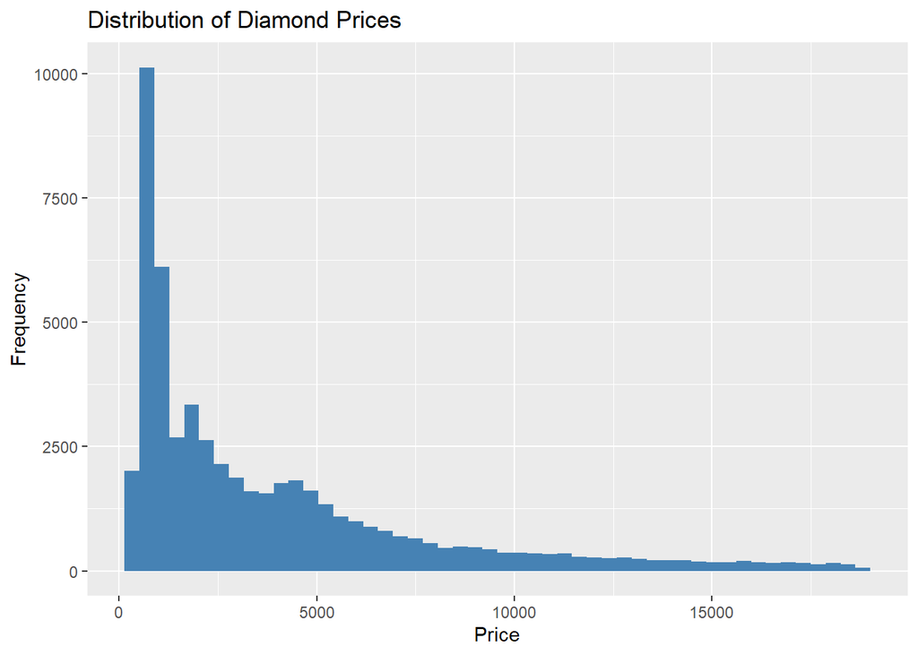

```r
ggplot(diamonds_clean, aes(x = price)) +
  geom_histogram(bins = 50, fill = "steelblue") +
  labs(
    title = "Distribution of Diamond Prices",
    x = "Price",
    y = "Frequency"
  )
```

### Key Insights:

- The distribution is **right-skewed**, meaning most diamonds are lower-priced, while only a few diamonds are extremely expensive.
- Most diamonds are concentrated in the lower price range, showing that **premium-quality diamonds are relatively rare.**
- The presence of very high-priced diamonds suggests that features like **larger carat size, better cut, clarity, and color quality** increase price significantly.

## 2. Relationship Between Carat and Price

Que2 - Does carat strongly influence price?

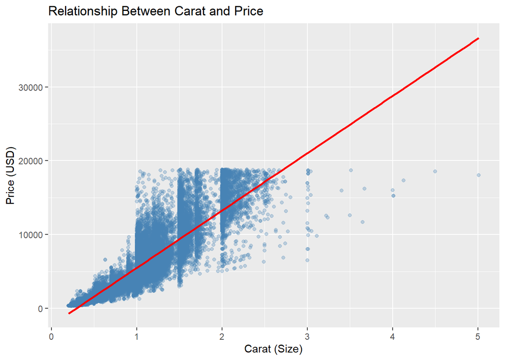

```r
ggplot(diamonds_clean, aes(x = carat, y = price)) +
  geom_point(alpha = 0.3, color = "steelblue") +
  geom_smooth(method = "lm", se = TRUE, color = "red") +
  labs(
    title = "Relationship Between Carat and Price",
    x = "Carat (Size)",
    y = "Price (USD)"
  )
```

### Key Insights:

- The scatter plot shows **a strong positive relationship** between carat and price.
- As carat size increases, diamond price generally increases significantly.
- The upward trend line confirms that **larger diamonds tend to be more expensive.**
- **Carat** appears to be one of the most influential factors in determining diamond price.

## 3. Average Price by Cut

Que3 - Which cut category has highest average price?

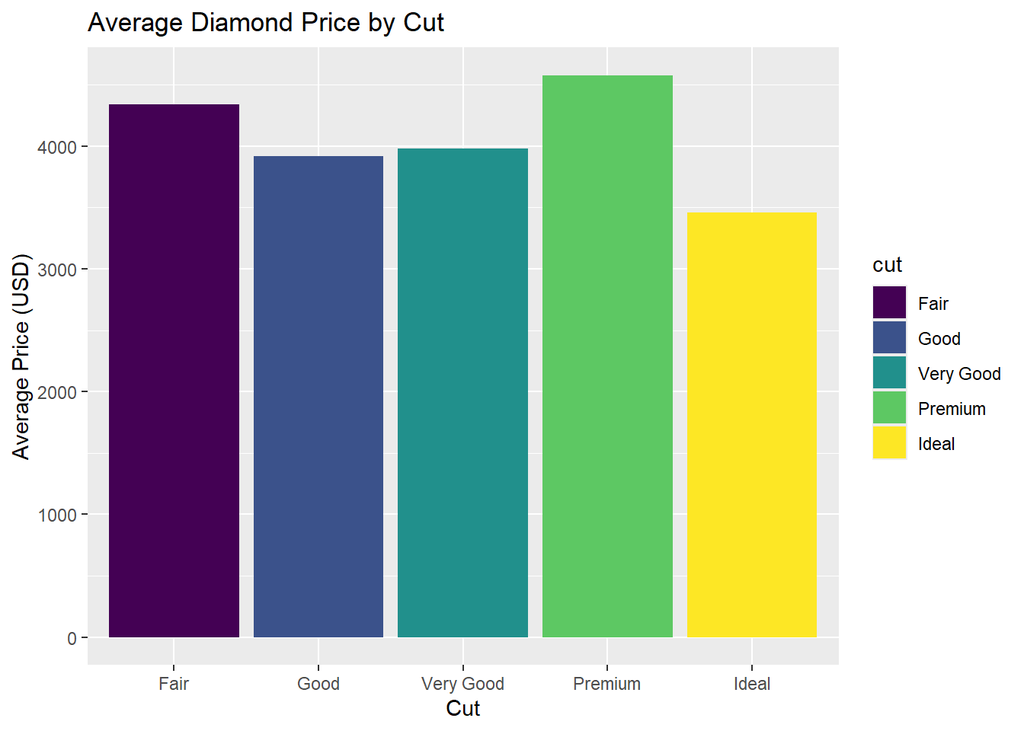

```r
diamonds_clean %>%
  group_by(cut) %>%
  summarise(avg_price = mean(price)) %>%
  ggplot(aes(x = cut, y = avg_price, fill = cut)) +
  geom_col() +
  labs(
    title = "Average Diamond Price by Cut",
    x = "Cut",
    y = "Average Price (USD)"
  )
```

### Key Insights:

- The **Premium** cut category has the **highest average diamond price** among all cut types.
- **Fair** cut diamonds also show relatively high average prices, possibly due to larger carat sizes in that category.
- **Ideal** cut diamonds have a lower average price compared to Premium and Fair cuts.
- This suggests that **cut quality alone does not determine price**. Factors like carat, clarity, and color also strongly influence pricing.

## 4. Price Distribution by Clarity

Que4 - Does clarity impact pricing?

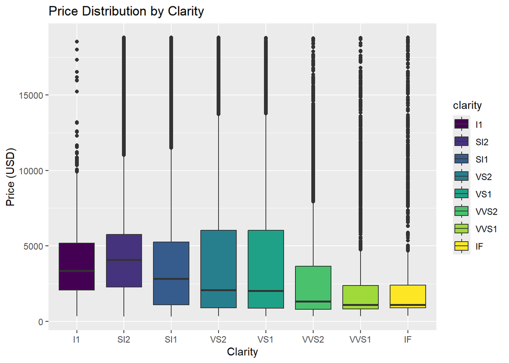

```r
ggplot(diamonds_clean, aes(x = clarity, y = price, fill = clarity)) +
  geom_boxplot() +
  labs(
    title = "Price Distribution by Clarity",
    x = "Clarity",
    y = "Price (USD)"
  )
```

### Key Insights:

- Diamond clarity impacts pricing, but the relationship is **not perfectly linear.**
- The wide spread and many outliers across clarity categories indicate that **price is influenced by multiple factors alongside clarity**.

## 5. Average Price by Diamond Color

Que5 - Which diamond color category has the highest average price?

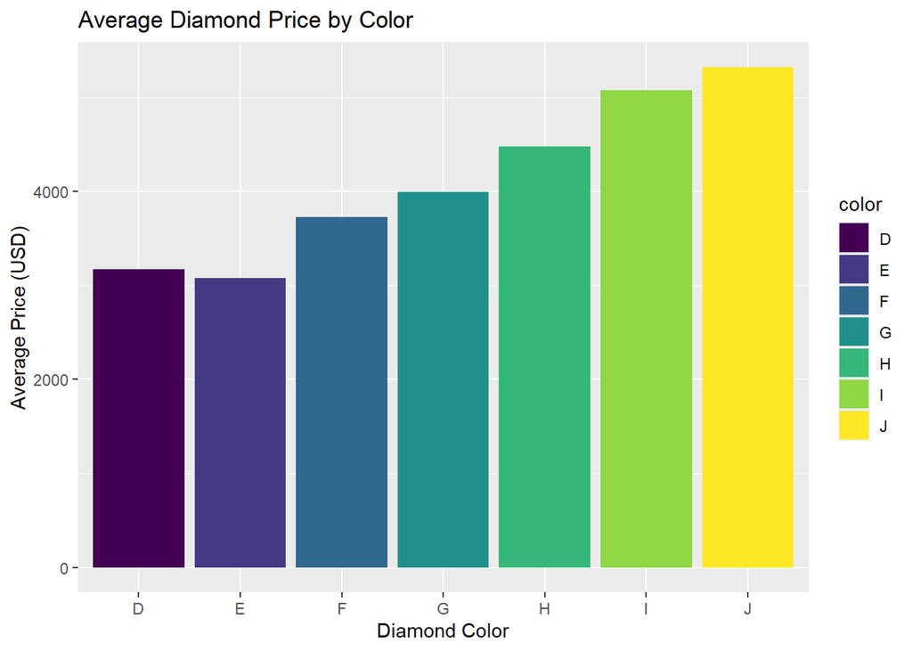

```r
diamonds_clean %>%
  group_by(color) %>%
  summarise(avg_price = mean(price)) %>%
  ggplot(aes(x = color, y = avg_price, fill = color)) +
  geom_col() +
  labs(
    title = "Average Diamond Price by Color",
    x = "Diamond Color",
    y = "Average Price (USD)"
  )
```

### Key Insights:

- The **J color** category has the **highest average** diamond price among all color grades.
- Average price generally increases from **D to J color categories** in this dataset.
- Lower color grades (such as I and J) having higher prices suggests that these diamonds may also have **larger carat sizes**, increasing their overall value.

# Statistical Analysis

```r
options(scipen = 999)
```

**Note:** This function forces R to show standard decimal numbers by turning off scientific notation.

## 1. Correlation Test Between Carat and Price

Que - Is there a strong relationship between carat and price?

H0: No linear relationship between Carat and Price H1: Relationship exists

```r
cor.test(
  diamonds_clean$carat,
  diamonds_clean$price
)
```

```
##
##  Pearson's product-moment correlation
##
## data:  diamonds_clean$carat and diamonds_clean$price
## t = 550.39, df = 53773, p-value < 0.00000000000000022
## alternative hypothesis: true correlation is not equal to 0
## 95 percent confidence interval:
##  0.9202643 0.9228128
## sample estimates:
##       cor
## 0.9215485
```

### Interpretation:

The correlation coefficient is: r = 0.9215

This indicates a **very strong positive correlation** between carat and price. (Larger diamonds tend to be much more expensive.)

- As the carat size increases, the price of diamonds also increases significantly.
- The p-value is extremely small (p < 0.00000000000000022), meaning the relationship is **statistically significant.**
- Since the p-value is far below 0.05 (significance level), we **reject the null hypothesis** and conclude that carat and price are significantly related.
- The 95% confidence interval (0.9203 to 0.9228) confirms that the true correlation is consistently very strong.

## 2. Chi-Square Test of Independence Between Cut and Color

Que - Is there a significant relationship between two categorical variables - Cut and Color?

H0: Variables are Independent (No relationship) H1: Variables are Dependent (Significant Relationship)

```r
chisq.test(
  diamonds_clean$cut,
  diamonds_clean$color
)
```

```
##
##  Pearson's Chi-squared test
##
## data:  diamonds_clean$cut and diamonds_clean$color
## X-squared = 306.7, df = 24, p-value < 0.00000000000000022
```

### Interpretation:

- The p-value is extremely small (p < 0.00000000000000022), which is far below 0.05.
- Therefore, we reject the null hypothesis of independence.
- This means there is a statistically significant relationship between diamond cut and color.
- Degree of Freedom (df): [Color = 7 Categories, Cut = 5 Categories] therefore, df = (7-1) x (5-1) = 6 x 4 = 24

## 3. One-Way ANOVA for Price Differences Across Cut Categories

Que - Do different cut categories have significantly different prices?

H0: The mean diamond prices are equal across all cut categories. H1: At least one cut category has a different mean diamond price.

```r
anova_model <- aov(
  price ~ cut,
  data = diamonds_clean
)

summary(anova_model)
```

```
##                Df       Sum Sq    Mean Sq F value              Pr(>F)
## cut             4  10788727783 2697181946   171.9 <0.0000000000000002 ***
## Residuals   53770 843548279132   15688084
## ---
## Signif. codes:  0 '***' 0.001 '**' 0.01 '*' 0.05 '.' 0.1 ' ' 1
```

### Interpretation:

This is a One-Way ANOVA (Analysis of Variance) test.

Independent Variable: **Cut** Dependent Variable: **Price**

The test compares the mean prices across different cut categories.

- The p-value is extremely small (p < 0.0000000000000002), which is far below 0.05.
- Therefore, we **reject the null hypothesis** that all cut categories have the same average price.
- This means there are significant differences in average diamond prices across cut categories.
- The high **F-value (171.9)** indicates that variation in price between cut groups is much larger than variation within groups.

# Conclusion

This project explored the diamonds dataset through:

- Data cleaning and validation
- Exploratory visualizations
- Statistical testing

The analysis helped identify relationships between: - Carat and price - Cut and price - Color and price - Cut and color